# Inference for Regression

November 4, 2020

## Recall: Evals Data

These data contain observations on 463 courses at the University of Texas Austin, with 23 variables recorded in the data:

- information about the course
- information about the professor
- information about number of students
- information about the “attractiveness” rating of the professor

Data from the 94 unique professors was randomly sampled, so that each row in the dataset corresponds to one course taught by that professor.

## Recall: Linear Regression

- Scores for average beauty can range from 0 to 10
- Ages range from 29 to 73, with a median of 47

## Visualization

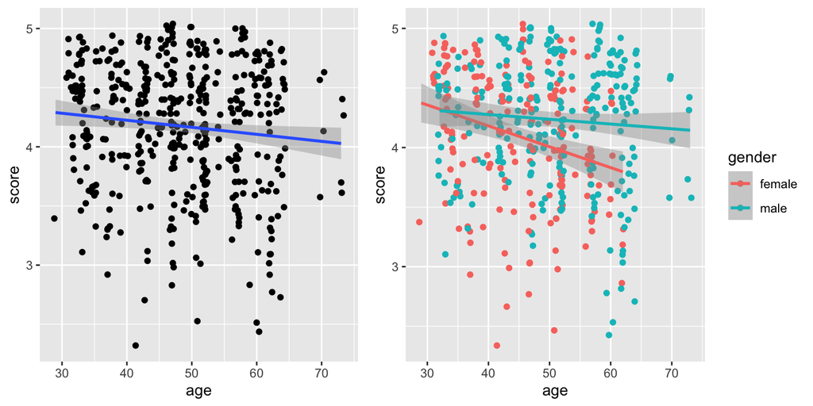

## Fitting a Model

```r
slr <- lm(score ~ age, data = evals)
get_regression_table(slr)
```

```
## # A tibble: 2 x 7
##   term      estimate std_error statistic p_value lower_ci upper_ci
##   <chr>        <dbl>     <dbl>     <dbl>   <dbl>    <dbl>    <dbl>
## 1 intercept    4.46      0.127     35.2    0        4.21     4.71
## 2 age         -0.006     0.003     -2.31   0.021   -0.011   -0.001
```

## Interpreting the Model

Using the values in the estimate column of the regression table we can obtain the equation of the “best-fitting” regression line from before:

\[ \widehat{\text{eval}} = 4.46 -0.006 \cdot \text{age} \]

**How would we interpret the slope on `age`?**

**What parameter is this an estimate of?**

## SE and Sampling Variability

```
## # A tibble: 2 x 2
##   estimate std_error
##      <dbl>     <dbl>
## 1    4.46      0.127
## 2   -0.006     0.003
```

- The standard error is the standard deviation of a point estimate calculated from the sample.
- A slope of -0.006 is just one possible value of the fitted slope.
  - If we collected a different sample of 94 professors we would almost certainly obtain a different fitted slope.
- The variability of the sampling distribution is also called the standard error!
  - The standard error quantifies how much variation in the fitted slope one would expect between different samples.

## Confidence Intervals

```
## # A tibble: 2 x 2
##   lower_ci upper_ci
##      <dbl>    <dbl>
## 1    4.21     4.71
## 2   -0.011   -0.001
```

- The two rightmost columns of the regression table correspond to the endpoints of the 95% confidence interval for the population slope \(\beta_1\).
  - A confidence interval can be thought of as a “net” for the population parameter.
  - A confidence interval of (-0.011, -0.001) is a range of plausible values for \(\beta_1\).

## Calculation of Confidence Interval

- `R` uses theory-based methods to acquire confidence intervals.
- Assuming that the sampling distribution is bellshaped, we can calculate a 95% confidence interval as:

\[ b_1 \pm 1.96 \cdot \text{SE}_{b_1} = -0.006 \pm 1.96 \cdot 0.003 \\ = (-0.0118, -0.0001) \]

```
## # A tibble: 2 x 2
##   lower_ci upper_ci
##      <dbl>    <dbl>
## 1    4.21     4.71
## 2   -0.011   -0.001
```

## Connection with Bootstrapping

- Bootstrapping re-samples from the original sample to see what other possible samples could have looked like.
  - The slope for each of these re-samples gives us a better idea of the sampling variability of the slope.

**What is the key assumption about the original sample when bootstrapping?**

- Bootstrapping with replacement is done row-by-row, so the original pairs of `score` and `age` are always kept together.

## Finding Bootstrap Statistics

```r
bootstrap_slope <- evals_small %>%
  specify(formula = score ~ age) %>%
  generate(reps = 1000, type = "bootstrap") %>%
  calculate(stat = "slope")

bootstrap_slope
```

```
## # A tibble: 1,000 x 2
##    replicate      stat
##        <int>     <dbl>
##  1         1 -0.00617
##  2         2  0.000574
##  3         3  0.00279
##  4         4 -0.000284
##  5         5 -0.00523
##  6         6 -0.00379
##  7         7 -0.00398
##  8         8 -0.00201
##  9         9 -0.00467
## 10        10 -0.00102
## # … with 990 more rows
```

## Calculating a Confidence Interval

```r
percentile_ci <- get_confidence_interval(bootstrap_slope, level = 0.95)
se_ci <- get_confidence_interval(bootstrap_slope, level = 0.95,
                                 type = "se", point_estimate = obs_slope)
```

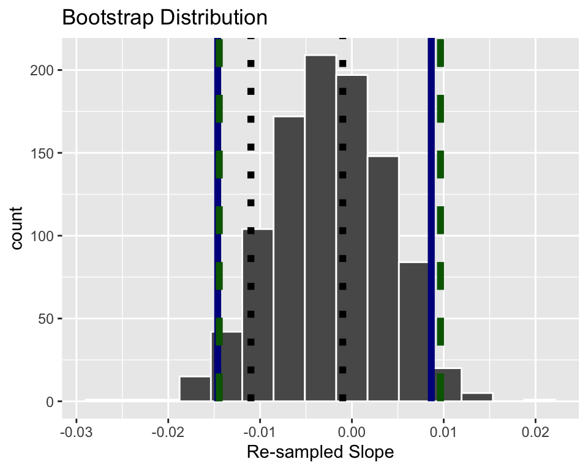

## Confidence Intervals & Hypothesis Tests

```
## # A tibble: 3 x 3
##   type        lower_ci upper_ci
##   <chr>          <dbl>    <dbl>
## 1 Percentile   -0.0146  0.00864
## 2 SE           -0.0144  0.00965
## 3 Theoretical  -0.011  -0.001
```

- A confidence provides a range of plausible values for the population parameter, here \(\beta_1.\)
  - If the null value (\(\beta_1 = 0\)) is contained in the interval, then 0 is a plausible value for \(\beta_1.\)

**What would you conclude for your hypothesis test?**

## Hypothesis Testing for the Slope

The statistic on the regression table tests between the hypotheses:

\[ H_0: \beta_1 = 0 \\ H_A: \beta_1 \neq 0 \]

*OR*

\(H_0:\) there is no true (linear) relationship between evaluation scores and age for all the instructors in our population

\(H_A:\) there is a (linear) relationship between evaluation scores and age for all the instructors in our population

## Test Statistic

```
## # A tibble: 1 x 3
##   term  statistic p_value
##   <chr>     <dbl>   <dbl>
## 1 age       -2.31   0.021
```

## Let’s Try Simulation Instead

```r
null_slope <- evals_small %>%
  specify(formula = score ~ age) %>%
  hypothesize(null = "independence") %>%
  generate(reps = 1000, type = "permute") %>%
  calculate(stat = "slope")

null_slope
```

```
## # A tibble: 1,000 x 2
##    replicate       stat
##        <int>      <dbl>
##  1         1 -0.00366
##  2         2  0.0154
##  3         3  0.00635
##  4         4  0.00376
##  5         5 -0.00755
##  6         6  0.0000792
##  7         7  0.00228
##  8         8 -0.00229
##  9         9  0.00526
## 10        10  0.00736
## # … with 990 more rows
```

## Calculating a p-value

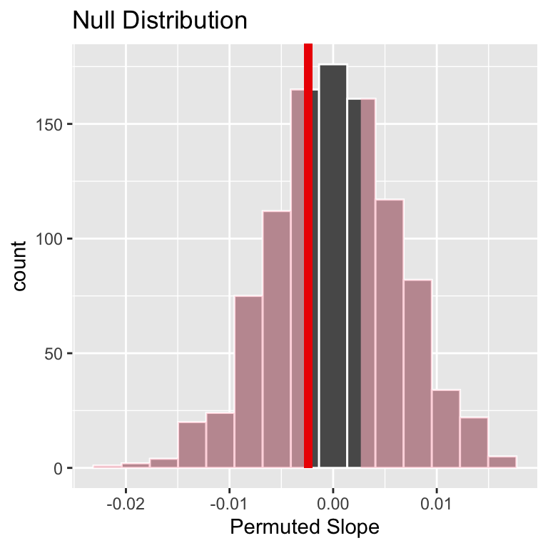

```
## # A tibble: 1 x 1
##   p_value
##     <dbl>
## 1   0.668
```

- What would you conclude for your hypothesis test?
- Using a \(t\)-distribution gets a p-value of 0.021. Why the difference?
- Would you have reached the same conclusion with your confidence interval?